# Weighted Cox Proportional Hazards Model

February 29, 2016

## Review of Cox PH model from EPID 722 2016 lecture and SAS code

NOTE: ALL SAS code below copied from 2016 EPID 722 lecture material. SAS code based on Steve Cole's program titled, "program7.17feb16.sas". R code below adapted to the SAS code by Ann Von Holle.

## Read file

## Read file

### SAS

```sas
libname mle "c:\temp";
%let dir = c:\temp;

* Read ASCII file;
data mle.b;
    infile "&dir\hividu15dec15.dat";
    input id 1-4 idu 6 white 8 age 10-11 cd4 13-16 drop 18 delta 20 @22 art 6.3 @29 t 6.3;
run;

* Export to .csv for use in R;
proc export data=mle.b outfile="c:\temp\hividu15dec15.csv" dbms=csv replace; run;
```

## Read file

### R

Read the data (created in the SAS program above).

```r
# getwd() # get the working directory
b = read.csv("c:/temp/hividu15dec15.csv", header = T)  # read in data.
```

## Look at data

## Look at data

### SAS

```sas
libname mle "c:\temp";
%let dir = c:\temp;
data a; set mle.b; run;

proc means data=a n mean sum min max;
    var delta t drop idu white age cd4;
    title "Time from 12/6/95 to AIDS or death in WIHS";
run;
```

```
Time from 12/6/95 to AIDS or death in WIHS

The MEANS Procedure

Variable       N            Mean             Sum         Minimum         Maximum
--------------------------------------------------------------------------------
delta       1164       0.4974227     579.0000000               0       1.0000000
t           1164       6.0907216         7089.60       0.0030000      10.0000000
drop        1164       0.1091065     127.0000000               0       1.0000000
idu         1164       0.3771478     439.0000000               0       1.0000000
white       1164       0.4226804     492.0000000               0       1.0000000
age         1164      36.4407216        42417.00      17.0000000      73.0000000
cd4         1164     393.5515464       458094.00               0         1933.00
--------------------------------------------------------------------------------
```

## Look at data

### R

```r
var.list = c("delta", "t", "drop", "idu", "white", "age", "cd4")

t.1 = CreateTableOne(data = b[, var.list])  # see https://cran.r-project.org/web/packages/tableone/vignettes/introduction.html
print(t.1, nonnormal = var.list)
```

```
                       Overall
  n                      1164
  delta (median [IQR])   0.00 [0.00, 1.00]
  t (median [IQR])       6.74 [2.12, 10.00]
  drop (median [IQR])    0.00 [0.00, 0.00]
  idu (median [IQR])     0.00 [0.00, 1.00]
  white (median [IQR])   0.00 [0.00, 1.00]
  age (median [IQR])    36.00 [31.00, 41.00]
  cd4 (median [IQR])   348.50 [212.75, 516.25]
```

## Background

Note: The following notation comes from lecture materials including "L3 Cox.pdf" lecture notes, program7.17feb16.sas, Cox model notes 15feb16.pdf. Also, Harrell book, chapter 20 (2) and Kleinbaum book (3).

## Survival function

\[ S(t) = Prob\{T >t \} = 1 - F(t) \]

\(S(t)\) is the probability that an event will occur after time \(t\) – or that the individual will survive without the event at least until time t. Conversely, \(F(t)\) is the risk that the event will occur before or at time \(t\).

## Hazard function

\[ h(t) = \displaystyle\lim_{\Delta \to 0} \displaystyle \frac{Prob(t \leq T < t + \Delta \mid T \geq t)}{\Delta} \]

"The hazard at time \(t\) is related to the probability that the event will occur in a small interval around \(t\), given that the event has not occured before time \(t\)." (2)

If you know the hazard you will know the cumulative hazard, \(H(t)\), and survival function, \(S(t)\). Likewise, knowing the survival function enables you to calculate the hazard function.

\[ \int_0^t h(v)dv = H(t) = -log(S(t)) \]

## Multivariable Cox model

\[ \begin{align} h_1(t \mid X) & = h_0(t) exp(\textbf{X} \mathbf{\beta}) \\ & = h_0(t) exp(X_1 \beta_1 + X_2 \beta_2 + \ldots ) \end{align} \]

where \(h_0(t)\) is the baseline hazard function.

## Partial likelihood for (without any ties or weights)

\[ L(\beta) = \displaystyle \prod_{Y_i \textrm{ uncensored}} \frac{exp(X_i \beta)}{\displaystyle\sum_{Y_j \geq Y_i} exp(X_j \beta)} \]

**Note**: no intercept term in the partial likelihood. Cancels out. Cox model a model for relative hazard.

## Interpretation of hazard ratio

- Assume linearity and additivity of covariates on the log hazard (or cumulative hazard) scale.
- Assume that the relative hazard remains constant over time. NOT the hazard remaining constant over time. For example, the hazard function is constant in an exponential model, \(h(t) = h\) with exponential distribution of time to event, \(t\).

**Interpretation**: The index group has xx times the hazard of the referent group. The Cox PH model coefficients will provide the log(hazard ratio).

## Other areas of interest

There are other important topics to cover, but not in these slides. See "L3 Cox.pdf" document for start.

- Details on model fit diagnostics including residuals
- Model choice
- Tied event times

## Crude Cox model

## Crude Cox model

### SAS

```sas
libname mle "c:\temp";
%let dir = c:\temp;
data a; set mle.b; run;

*Crude Cox model;
proc phreg data=a;
    model t*delta(0)=idu/rl ties=efron;
    *default is ties=breslow, ties=efron is better;
    ods select  parameterestimates;
*   ods select modelinfo fitstatistics parameterestimates;
    *this ods statement makes the print out nicer;
    title "Crude Cox model";
run; quit;
```

```
Crude Cox model

The PHREG Procedure

               Analysis of Maximum Likelihood Estimates

                    Parameter      Standard
Parameter    DF      Estimate         Error    Chi-Square    Pr > ChiSq

idu           1       0.54197       0.08335       42.2766        <.0001

  Analysis of Maximum Likelihood Estimates

               Hazard      95% Hazard Ratio
Parameter       Ratio      Confidence Limits

idu             1.719       1.460       2.025
```

## Crude Cox model

### R

```r
s.1 = coxph(Surv(t, delta) ~ idu, data = b, ties = "efron")
coef(summary(s.1))
```

```
         coef exp(coef)   se(coef)        z     Pr(>|z|)
idu 0.5419405   1.71934 0.08335408 6.501668 7.943435e-11
```

## Adjusted Cox model

### SAS

```sas
libname mle "c:\temp";
%let dir = c:\temp;
data a; set mle.b; run;

*Adjusted Cox model;
proc phreg data=a;
    model t*delta(0)=idu age white cd4/rl ties=efron;
*   ods select modelinfo fitstatistics parameterestimates;
    ods select parameterestimates;
    title "Adjusted Cox model";
run; quit;
```

```
Adjusted Cox model

The PHREG Procedure

               Analysis of Maximum Likelihood Estimates

                    Parameter      Standard
Parameter    DF      Estimate         Error    Chi-Square    Pr > ChiSq

idu           1       0.49602       0.08734       32.2511        <.0001
age           1       0.00997       0.00529        3.5507        0.0595
white         1      -0.17464       0.08639        4.0862        0.0432
cd4           1      -0.00158     0.0002044       60.0845        <.0001

  Analysis of Maximum Likelihood Estimates

               Hazard      95% Hazard Ratio
Parameter       Ratio      Confidence Limits

idu             1.642       1.384       1.949
age             1.010       1.000       1.021
white           0.840       0.709       0.995
cd4             0.998       0.998       0.999
```

## Adjusted Cox model

### R

```r
s.2 = update(s.1, formula = Surv(t, delta) ~ idu + age + white +
    cd4)  # add confounder to crude model in s.1
coef(summary(s.2))
```

```
              coef exp(coef)     se(coef)         z     Pr(>|z|)
idu    0.496015614 1.6421652 0.0873420374  5.679002 1.354828e-08
age    0.009968916 1.0100188 0.0052904566  1.884321 5.952163e-02
white -0.174635614 0.8397630 0.0863914008 -2.021447 4.323354e-02
cd4   -0.001584309 0.9984169 0.0002043882 -7.751471 9.103829e-15
```

## Check proportional hazards assumption

See slide 36 of "L3 Cox.pdf" document for more details.

## Check proportional hazards assumption, SAS, 1

```sas
libname mle "c:\temp";
%let dir = c:\temp;
data a; set mle.b; run;

*Assess PH assumption;
*First look at plot of log H(t) by t;
proc phreg data=a ;
    model t*delta(0)=;
    strata idu;
    baseline out=b cumhaz=caph/method=pl;
ods select parameterestimates;
data b; set b; if caph>0 then logcaph=log(caph);

ods listing gpath="&dir";
ods graphics / reset imagename="logcumhaz" imagefmt=jpeg height=5in width=5in;
proc sgplot data=b noautolegend;
    title "log H(t) by time";
    step x=t y=logcaph/group=idu;
run;
```

## Check proportional hazards assumption, SAS, 2

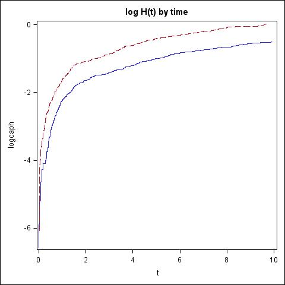

## Check proportional hazards assumption, SAS, 3

```sas
libname mle "c:\temp";
%let dir = c:\temp;
data a; set mle.b; run;

*Second test product of idu and t;
proc phreg data=a;
    model t*delta(0)=idu idut / rl ties=efron;
    idut=idu*t; * should it be log time?;
  ods select parameterestimates;
    title "Crude Cox model, testing PH assumption";
run;
```

```
Crude Cox model, testing PH assumption

The PHREG Procedure

               Analysis of Maximum Likelihood Estimates

                    Parameter      Standard
Parameter    DF      Estimate         Error    Chi-Square    Pr > ChiSq

idu           1       0.62772       0.13211       22.5769        <.0001
idut          1      -0.02581       0.03089        0.6982        0.4034

  Analysis of Maximum Likelihood Estimates

               Hazard      95% Hazard Ratio
Parameter       Ratio      Confidence Limits

idu             1.873       1.446       2.427
idut            0.975       0.917       1.035
```

Second test looks at significance of interaction between time and **idu** effect. Book on survival analysis by Paul Allison (4) has good examples of handling interaction with time in SAS. (from page 153+)

## Check proportional hazards assumption, R, 1

NOTE: all code in this section for time dependent covariates copied from [this paper](https://www.jstatsoft.org/index.php/jss/article/view/v061c01/v61c01.pdf), titled "Tutorial: Survival Estimation for Cox Regression Models with Time-Varying Coefficients Using SAS and R"

```r
cut.points <- unique(b$t[b$delta == 1])  # get unique time points for event

SURV2 <- survSplit(data = b, cut = cut.points, end = "t", start = "time0",
    event = "delta")  # make counting process data
```

## Check proportional hazards assumption, R, 2

"To make the appearance match SAS, we sort SURV2 by subject then rename and reorder the columns."

```r
SURV2 <- SURV2[order(SURV2$id), ]
names(SURV2)
```

```
 [1] "id"    "idu"   "white" "age"   "cd4"   "drop"  "delta" "art"
 [9] "t"     "time0"
```

```r
SURV2 <- SURV2[, c("id", "idu", "white", "age", "cd4", "time0",
    "t", "delta")]
names(SURV2)[7] = "time1"
```

## Check proportional hazards assumption, R, 3

Add a time dependent covariate associated with **idu**.

```r
SURV2$lt.idu = with(SURV2, idu * time1)
s.5 = coxph(Surv(time0, time1, delta) ~ idu + lt.idu, data = SURV2)
coef(summary(s.5))
```

```
             coef exp(coef)   se(coef)          z     Pr(>|z|)
idu     0.6277487 1.8733883 0.13211011  4.7517084 2.017051e-06
lt.idu -0.0258296 0.9745011 0.03089455 -0.8360567 4.031230e-01
```

## Check proportional hazards assumption, R, 2 (extra)

Also, you can look at [an R shiny app](https://vonholleunc.shinyapps.io/survival/) that allows you to modify parameters in a Cox model to see different types of proportional hazards assumptions violations.

https://vonholleunc.shinyapps.io/survival/

## Nice table of Cox PH model assumptions (2) – optional

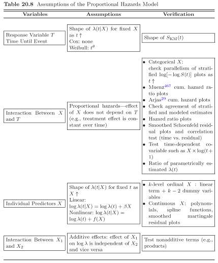

## Hazard and calculate crude Cox model by hand

## Calculate crude Cox model by hand (SAS)

See Appendix A, p2430, of assigned reading (5) for estimate of hazard, \(h(t)\).

- \(Y_k\) is the number of individuals who died at each of the ranked times \(R_k\).
- \(N_k\) is the number of individuals at-risk for mortality while under observation at distinct ranked event time \(R_k\) for \(k = 1, \ldots, D^{\prime}\).

\(h_k = \frac{Y_k}{N_k \Delta_k}\) where \(\Delta_k = R_k - R_{k-1}\) and \(R_0=0\) and \(R_k\) is observed event time at rank \(k\).

The cumulative hazard, \(H(t)\) is estimated as \(H^{KM}_t = -log(S^{KM}(t))\).

## Calculate crude Cox model by hand (SAS), 1

Data set 'a' contains the survival data set.

Data set 'b' contains the survival function, \(S(t)\) at each unique time point.

Data set 'c' provides the number at risk, \(N_k\) for each unique time interval in the 'a' data set.

```sas
libname mle "c:\temp";
%let dir = c:\temp;
data a; set mle.b; run;

*Get KM estimators of survival functions for each treatment group;
proc phreg data=a noprint;
    model t*delta(0)=;
    strata idu;
    baseline out=b survival=s / method=pl;
    output out=c(keep=idu t n) atrisk=n/method=pl;
*Merge together survival data with numbers at risk;
proc sort data=b;
    by idu descending s;
proc sort data=c nodups; by idu t;
data c; set c; by idu t; if first.t;
data mle.d; merge b c; by idu t; if s>.;
run;

title 'data set a';
proc print data=a(obs=10); run;

title 'data set b';
proc print data=b(obs=10); run;

title "data set c";
proc print data=c(obs=10); run;
```

```
data set a

 Obs    id    idu    white    age    cd4    drop    delta     art        t

   1     1     1       0       44    376      0       1       .        2.245
   2     2     1       1       32    392      0       1       .        1.213
   3     3     0       0       44    181      0       0      1.224    10.000
   4     4     1       0       35    526      0       1       .        1.240
   5     5     1       1       46    386      0       1       .        7.871
   6     6     0       1       29    285      0       1      2.207     6.593
   7     7     1       0       34    358      0       1       .        1.191
   8     8     0       1       39    708      0       1      2.300     5.098
   9     9     1       0       45    840      0       1       .        2.226
  10    10     0       0       47    274      0       1       .        8.761



data set b

Obs    idu      t         s

  1     0     0.000    1.00000
  2     0     0.003    0.99862
  3     0     0.011    0.99724
  4     0     0.016    0.99586
  5     0     0.019    0.99448
  6     0     0.074    0.99310
  7     0     0.079    0.99172
  8     0     0.090    0.99034
  9     0     0.120    0.98897
 10     0     0.131    0.98621



data set c

Obs    idu      t       n

  1     0     0.003    725
  2     0     0.011    724
  3     0     0.016    723
  4     0     0.019    722
  5     0     0.074    721
  6     0     0.079    720
  7     0     0.090    719
  8     0     0.120    718
  9     0     0.131    717
 10     0     0.172    715
```

## Calculate crude Cox model by hand (SAS), 2

```sas
libname mle "c:\temp";
%let dir = c:\temp;
data d; set mle.d; run;

*Calculate the log hazard functions;
*This is a fairly complicated program, but largely repeats last session;
data mle.d(drop=chm1 sm1 tm1) avg(keep=avg0 avg1);
    set d end=end;
    by idu descending s;
    retain chm1 0 sm1 1 tm1 0 sum0 0 sum1 0 count0 0 count1 0;
    if t=0 then do;
        d=0; chm1=0; sm1=1; tm1=0; n=.;
    end;
    deltat=t-tm1;
    if s>0 then ch=-log(s);
    y=round((ch-chm1)*n,1);
    if deltat>0 then h=y/(n*deltat);
    label n=;
    logh=log(h);
    if idu=0 and logh>. then do; count0=count0+y; sum0=sum0+logh; end;
    else if idu=1 and logh>. then do; count1=count1+y; sum1=sum1+logh; end;
    output mle.d;
    chm1=ch; sm1=s; tm1=t;
    if end then do; avg0=sum0/count0; avg1=sum1/count1; output avg; end;
run;

title 'data set d';
proc print data=mle.d(obs=10); run;
```

## Calculate crude Cox model by hand (SAS), 2

```
data set d

                                    c c     d
                                    o o     e
                            s    s  u u     l                          l    a a
 O  i                       u    u  n n     t                          o    v v
 b  d                       m    m  t t     a       c                  g    g g
 s  u   t      s     n      0    1  0 1 d   t       h    y    h        h    0 1

  1 0 0.000 1.00000   .   0.0000 0  0 0 0 0.000 0.000000 .  .        .      . .
  2 0 0.003 0.99862 725  -1.5541 0  2 0 . 0.003 0.001380 1 0.45977 -0.77703 . .
  3 0 0.011 0.99724 724  -4.2900 0  3 0 . 0.008 0.002762 1 0.17265 -1.75648 . .
  4 0 0.016 0.99586 723  -5.1037 0  4 0 . 0.005 0.004147 1 0.27663 -1.28509 . .
  5 0 0.019 0.99448 722  -5.3644 0  5 0 . 0.003 0.005533 1 0.46168 -0.77288 . .
  6 0 0.074 0.99310 721 -11.9519 0  6 0 . 0.055 0.006920 1 0.02522 -3.68022 . .
  7 0 0.079 0.99172 720 -10.8336 0  7 0 . 0.005 0.008310 1 0.27778 -1.28093 . .
  8 0 0.090 0.99034 719 -13.6886 0  8 0 . 0.011 0.009702 1 0.12644 -2.06800 . .
  9 0 0.120 0.98897 718 -17.7605 0  9 0 . 0.030 0.011096 1 0.04643 -3.06991 . .
 10 0 0.131 0.98621 717 -17.4347 0 12 0 . 0.011 0.013889 2 0.25358 -1.37207 . .
```

## Calculate crude Cox model by hand (SAS), 3

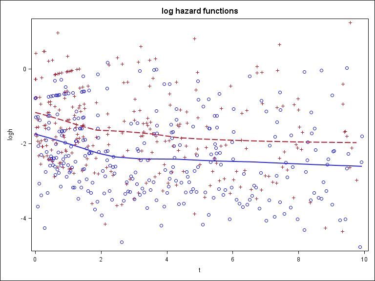

```sas
libname mle "c:\temp";
%let dir = c:\temp;
data d; set mle.d; run;

ods listing gpath="&dir";
ods graphics/reset imagename="Hazards" imagefmt=jpeg height=6in width=8in;
proc sgplot data=d noautolegend;
    title "log hazard functions";
    loess x=t y=logh/smooth=.6 group=idu;
run;
```

## Calculate crude Cox model by hand (R)

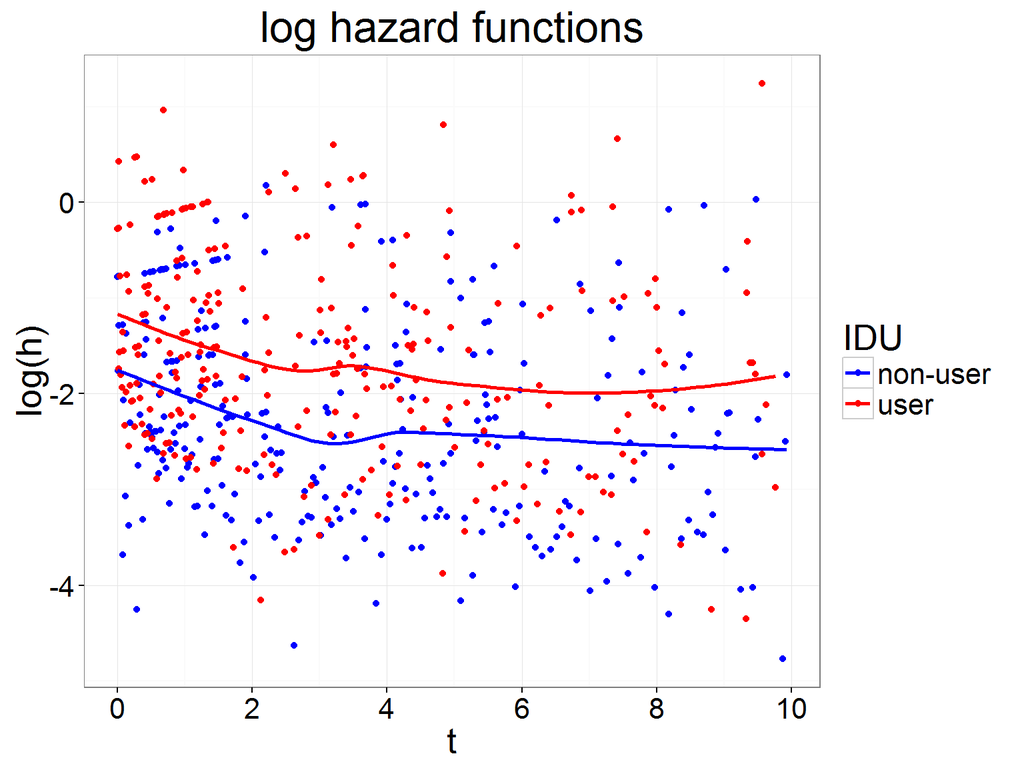

```r
est.1 = survfit(Surv(t, delta) ~ 1 + strata(idu), data = b)
sum.surv = summary(est.1)

d = with(sum.surv, {
    data.frame(t = time, n = n.risk, r = 1 - surv, s = surv,
        n.event = n.event, n.censor = n.censor, se = std.err,
        se2 = surv * sqrt((1 - surv)/n.risk), idu = strata)
})
d$idu = ifelse(d$idu == "strata(idu)=idu=0", 0, 1)
head(d)
table(d$idu)  # check

d.rev = rbind(c(t = 0, n = d$n[1], r = NA, s = NA, n.event = 0,
    n.censor = NA, se = NA, se2 = NA, idu = 0), c(t = 0, n = d$n[1],
    r = NA, s = NA, n.event = 0, n.censor = NA, se = NA, se2 = NA,
    idu = 1), d)  # add a time origin point here for each strata.

# use data.table package to get time diff by strata. see
# http://bit.ly/1PV1wPn
d.rev.dt = data.table(d.rev)
setkey(d.rev.dt, idu)
d.rev.dt[, `:=`(delta.t, c(0, diff(as.matrix(t)))), by = idu][,
    `:=`(h, n.event/(n * delta.t))]

some.vars = c("t", "n.event", "n", "delta.t", "h", "idu")
head(d.rev.dt[, some.vars, with = F])  # check with SAS numbers

p.haz = ggplot(data = d.rev.dt, aes(x = t, y = log(h), group = factor(idu),
    colour = factor(idu))) + geom_point() + stat_smooth(method = "loess",
    se = F) + scale_x_continuous(breaks = c(0, 2, 4, 6, 8, 10)) +
    theme_bw() + scale_colour_manual(values = c("blue", "red"),
    name = "IDU", breaks = c(0, 1), labels = c("non-user", "user")) +
    ggtitle("log hazard functions") + theme(text = element_text(size = 20))
```

## IP-weighted Cox model

## Confounding weights (SAS), 1

Output the stabilized IP weight, \(\displaystyle\frac{Pr(A_i=a)}{Pr(A_i=a \mid \mathbf{C})}\) where \(A\) is the exposure (IDU in this example) and \(\mathbf{C}\) = vector of covariates including **white**, **age**, **cd4** as confounders. The **n** data set contains the numerator of stabilized IP weight and the **d** data set contains the denominator of the stabilized IP weight.

```sas
libname mle "c:\temp";
%let dir = c:\temp;
data a; set mle.b; run;

* Confounding weights;
proc logistic data=a desc noprint; model idu=; output out=mle.n p=num; run;
proc print data=mle.n(obs=10); run;

proc logistic data=a desc noprint; model idu=white age cd4; output out=mle.d p=den; run;
proc print data=mle.d(obs=10); run;
```

```
 Obs  id  idu  white  age  cd4  drop  delta   art      t    _LEVEL_    num

   1   1   1     0     44  376    0     1     .      2.245     1     0.37715
   2   2   1     1     32  392    0     1     .      1.213     1     0.37715
   3   3   0     0     44  181    0     0    1.224  10.000     1     0.37715
   4   4   1     0     35  526    0     1     .      1.240     1     0.37715
   5   5   1     1     46  386    0     1     .      7.871     1     0.37715
   6   6   0     1     29  285    0     1    2.207   6.593     1     0.37715
   7   7   1     0     34  358    0     1     .      1.191     1     0.37715
   8   8   0     1     39  708    0     1    2.300   5.098     1     0.37715
   9   9   1     0     45  840    0     1     .      2.226     1     0.37715
  10  10   0     0     47  274    0     1     .      8.761     1     0.37715



 Obs  id  idu  white  age  cd4  drop  delta   art      t    _LEVEL_    den

   1   1   1     0     44  376    0     1     .      2.245     1     0.54431
   2   2   1     1     32  392    0     1     .      1.213     1     0.26136
   3   3   0     0     44  181    0     0    1.224  10.000     1     0.52111
   4   4   1     0     35  526    0     1     .      1.240     1     0.36937
   5   5   1     1     46  386    0     1     .      7.871     1     0.54445
   6   6   0     1     29  285    0     1    2.207   6.593     1     0.20563
   7   7   1     0     34  358    0     1     .      1.191     1     0.33129
   8   8   0     1     39  708    0     1    2.300   5.098     1     0.43098
   9   9   1     0     45  840    0     1     .      2.226     1     0.61930
  10  10   0     0     47  274    0     1     .      8.761     1     0.59637
```

## Confounding weights (SAS), 2

Merge those stabilized weights, **n** and **d**, with the source data set, **a**, to get the **c** data set.

```sas
libname mle "c:\temp";
%let dir = c:\temp;
data a; set mle.b; run;
data n; set mle.n; run;
data d; set mle.d; run;

data mle.c; merge a n d;
    if idu then w=num/den;
    else w = (1-num)/(1-den);
    label num= den=;
    drop _level_;
run; quit;

title "data set c";
proc print data=mle.c(obs=10); var id t num den w; run;
```

```
data set c

 Obs    id       t        num        den         w

   1     1     2.245    0.37715    0.54431    0.69290
   2     2     1.213    0.37715    0.26136    1.44301
   3     3    10.000    0.37715    0.52111    1.30062
   4     4     1.240    0.37715    0.36937    1.02106
   5     5     7.871    0.37715    0.54445    0.69272
   6     6     6.593    0.37715    0.20563    0.78408
   7     7     1.191    0.37715    0.33129    1.13843
   8     8     5.098    0.37715    0.43098    1.09460
   9     9     2.226    0.37715    0.61930    0.60899
  10    10     8.761    0.37715    0.59637    1.54314
```

## Confounding weights (using the ipw package) (R), 1

```r
ipw.idu = ipwpoint(
  exposure = idu,
  family = "binomial",
  link = "logit",
  numerator = ~ 1,
  denominator = ~ white + age + cd4, # note if numerator unspecified the default is 1
  data=b)

cbind(b[1:10, c("id", "t")], ipw.idu$ipw.weights[1:10])
```

## Confounding weights (using the ipw package) (R), 2

```
   id      t ipw.idu$ipw.weights[1:10]
1   1  2.245                 0.6928972
2   2  1.213                 1.4430101
3   3 10.000                 1.3006181
4   4  1.240                 1.0210625
5   5  7.871                 0.6927161
6   6  6.593                 0.7840825
7   7  1.191                 1.1384290
8   8  5.098                 1.0946014
9   9  2.226                 0.6089875
10 10  8.761                 1.5431381
```

## IP-censoring weights (SAS), 1

Take the data set with the IP weights, **w**, and get the quintiles for the censoring times: the data set named **q**.

```sas
libname mle "c:\temp";
%let dir = c:\temp;

*IP-censoring weights;
data mle.c; set mle.c; retain z 1; run;

proc univariate data=mle.c noprint; where drop=1; var t;
    output out=q pctlpts=20 40 60 80 pctlpre=p;
run;

data mle.q; set q; p0=0; p100=10; z=1;
proc print data=mle.q; run; * check quantiles to compare with R;
```

```
Obs     p20      p40      p60      p80     p0    p100    z

 1     1.613    3.455    5.791    7.414     0     10     1
```

## IP-censoring weights (SAS), 2

Take those quintiles and make up to five separate rows per person in the **c** data set based on time intervals with cut points according to the quintiles. These data form the **e** data set. Each person has a max of five rows, but if they were censored or had an event before the last time point then that person only has however many rows in which they are still in the risk set.

```sas
libname mle "c:\temp";
%let dir = c:\temp;
data q; set mle.q; run;
data c; set mle.c; run;

data mle.e; merge c q; by z;
    array j{6} p0 p20 p40 p60 p80 p100;
    do k=1 to 5;
        in=j(k);
        if j(k)<t<=j(k+1) then do;
            out=t;
            delta2=delta; *make a time-varying event indicator;
            _drop=drop; *make a time-varying drop indicator;
            output;
        end;
        else if j(k+1)<t then do; out=j(k+1); delta2=0; _drop=0; output; end;
    end;
proc sort data=mle.e; by id in; run;
proc print data=mle.e(obs=10); run;
```

## IP-censoring weights (SAS), 2

```
 Obs id idu white age cd4 drop delta  art     t     num     den      w

   1  1  1    0    44 376   0    1    .     2.245 0.37715 0.54431 0.69290
   2  1  1    0    44 376   0    1    .     2.245 0.37715 0.54431 0.69290
   3  2  1    1    32 392   0    1    .     1.213 0.37715 0.26136 1.44301
   4  3  0    0    44 181   0    0   1.224 10.000 0.37715 0.52111 1.30062
   5  3  0    0    44 181   0    0   1.224 10.000 0.37715 0.52111 1.30062
   6  3  0    0    44 181   0    0   1.224 10.000 0.37715 0.52111 1.30062
   7  3  0    0    44 181   0    0   1.224 10.000 0.37715 0.52111 1.30062
   8  3  0    0    44 181   0    0   1.224 10.000 0.37715 0.52111 1.30062
   9  4  1    0    35 526   0    1    .     1.240 0.37715 0.36937 1.02106
  10  5  1    1    46 386   0    1    .     7.871 0.37715 0.54445 0.69272

 Obs z   p20    p40    p60    p80   p0  p100  k    in     out   delta2  _drop

   1 1  1.613  3.455  5.791  7.414   0   10   1  0.000   1.613     0      0
   2 1  1.613  3.455  5.791  7.414   0   10   2  1.613   2.245     1      0
   3 1  1.613  3.455  5.791  7.414   0   10   1  0.000   1.213     1      0
   4 1  1.613  3.455  5.791  7.414   0   10   1  0.000   1.613     0      0
   5 1  1.613  3.455  5.791  7.414   0   10   2  1.613   3.455     0      0
   6 1  1.613  3.455  5.791  7.414   0   10   3  3.455   5.791     0      0
   7 1  1.613  3.455  5.791  7.414   0   10   4  5.791   7.414     0      0
   8 1  1.613  3.455  5.791  7.414   0   10   5  7.414  10.000     0      0
   9 1  1.613  3.455  5.791  7.414   0   10   1  0.000   1.240     1      0
  10 1  1.613  3.455  5.791  7.414   0   10   1  0.000   1.613     0      0
```

## IP-censoring weights (SAS), 3

Find the \(Pr(\_drop=0 \mid in)\) where \(in\) is equal to the five groups of time intervals and \(\_drop\) is the drop out indicator variable, _drop=1 if a person drops out at time \(in\), 0 otherwise. This value equals the numerator of the drop out weight, **nm2**.

```sas
libname mle "c:\temp";
%let dir = c:\temp;
data e; set mle.e; run;

proc logistic data=e noprint;
    class in/param=ref desc;
    model _drop=in;
    output out=mle.nm2(keep=id _drop nm2 in out) prob=nm2;
run;
proc print data=mle.nm2(obs=10); run;
```

```
 Obs    id      in       out     _drop      nm2

   1     1    0.000     1.613      0      0.97766
   2     1    1.613     2.245      0      0.97250
   3     2    0.000     1.213      0      0.97766
   4     3    0.000     1.613      0      0.97766
   5     3    1.613     3.455      0      0.97250
   6     3    3.455     5.791      0      0.96671
   7     3    5.791     7.414      0      0.96006
   8     3    7.414    10.000      0      0.95455
   9     4    0.000     1.240      0      0.97766
  10     5    0.000     1.613      0      0.97766
```

## IP-censoring weights (SAS), 4

Find the \(Pr(\_drop=0 \mid in, idu, white, age, cd4)\). This value will be the denominator of the drop out weight, **dn2**.

```sas
libname mle "c:\temp";
%let dir = c:\temp;
data e; set mle.e; run;

proc logistic data=e noprint;
    class in/param=ref desc;
    model _drop=in idu white age cd4;
    output out=mle.dn2(keep=id _drop dn2 in out) prob=dn2;
run;
proc print data=mle.dn2(obs=10); run;
```

```
 Obs    id      in       out     _drop      dn2

   1     1    0.000     1.613      0      0.98961
   2     1    1.613     2.245      0      0.98773
   3     2    0.000     1.213      0      0.98168
   4     3    0.000     1.613      0      0.98384
   5     3    1.613     3.455      0      0.98093
   6     3    3.455     5.791      0      0.97718
   7     3    5.791     7.414      0      0.97305
   8     3    7.414    10.000      0      0.96911
   9     4    0.000     1.240      0      0.98640
  10     5    0.000     1.613      0      0.98544
```

## IP-censoring weights (SAS), 5

\[ \textrm{ipcw}_{it}^{} = \displaystyle\frac{ Pr(D_i > t)}{Pr(D_i > t \mid \textrm{cov}_i^{})} = \displaystyle\prod_{q \leq t} \displaystyle\frac{Pr(D_i(q)=0)}{Pr(D_i(q)=0 \mid \mathbf{cov}_i)} \]

- Notation
  - \(D_i(q)\) = drop out status for individual \(i\) at time \(q\) (1=yes, 0=no)
  - \(Pr(D_i(q)=0)\) is "…marginal proportion who had not dropped out by time \(q\)." (6)
  - \(\mathbf{cov}_i\) = covariate values for individual \(i\) that are common causes of drop out and study outcome for individual \(i\) up to time \(t\).

## IP-censoring weights (SAS), 5

```sas
libname mle "c:\temp";
%let dir = c:\temp;
data nm2; set mle.nm2; run;
data dn2; set mle.dn2; run;
data e; set mle.e(drop=num den); run; *if you do not take out num den variable associated with confounding weights they will mess up code that follows to make censoring weights;

proc sort data=nm2; by id in;
proc sort data=dn2; by id in;

data f; merge e nm2 dn2; by id in; retain num den;
    if first.id then do; num=1; den=1; end;
    num=num*nm2;
    den=den*dn2;
    if _drop then w2=(1-num)/(1-den);  else w2=num/den;
    w3=w*w2;
    label nm2= dn2=;
    run;

proc print data=f(obs=10); var id in out _drop nm2 dn2 num den w w2 w3; run;
data mle.f; set f; run; * make permanent data set for next step.;
```

```
                    _
                    d
  O             o   r    n       d       n       d
  b  i   i      u   o    m       n       u       e               w       w
  s  d   n      t   p    2       2       m       n       w       2       3

   1 1 0.000  1.613 0 0.97766 0.98961 0.97766 0.98961 0.69290 0.98792 0.68453
   2 1 1.613  2.245 0 0.97250 0.98773 0.95077 0.97747 0.69290 0.97269 0.67398
   3 2 0.000  1.213 0 0.97766 0.98168 0.97766 0.98168 1.44301 0.99591 1.43711
   4 3 0.000  1.613 0 0.97766 0.98384 0.97766 0.98384 1.30062 0.99372 1.29245
   5 3 1.613  3.455 0 0.97250 0.98093 0.95077 0.96508 1.30062 0.98517 1.28133
   6 3 3.455  5.791 0 0.96671 0.97718 0.91912 0.94306 1.30062 0.97462 1.26761
   7 3 5.791  7.414 0 0.96006 0.97305 0.88242 0.91764 1.30062 0.96162 1.25069
   8 3 7.414 10.000 0 0.95455 0.96911 0.84231 0.88930 1.30062 0.94716 1.23189
   9 4 0.000  1.240 0 0.97766 0.98640 0.97766 0.98640 1.02106 0.99114 1.01202
  10 5 0.000  1.613 0 0.97766 0.98544 0.97766 0.98544 0.69272 0.99211 0.68725
```

## IP-censoring weights (SAS), 5

Summary of: 1) the IP weight, **w**, 2) the censoring weight, **w2**, and 3) the product of the two weights, **w3**.

```sas
libname mle "c:\temp";
proc means data=mle.f;
    var w w2 w3 num den;
    title "IP-weights";
    run;
```

```
IP-weights

The MEANS Procedure

Variable       N            Mean         Std Dev         Minimum         Maximum
--------------------------------------------------------------------------------
w           4030       1.0164930       0.5081338       0.4207657       7.4901897
w2          4030       1.0011560       0.0862268       0.3545261       2.5326918
w3          4030       1.0159825       0.5036598       0.2960679       7.4248374
num         4030       0.9269853       0.0465738       0.8423067       0.9776632
den         4030       0.9261747       0.0591954       0.4960065       0.9940851
--------------------------------------------------------------------------------
```

## IP-censoring weights (R)

### Quantiles in R

```r
# Set up the data frame with counting process style data
b$replicate = 0
b.dt = data.table(b)
# try to get quantiles as close to SAS as possible
# documentation for quantile function in R says type 3
quantile(b.dt[b.dt$drop == 1, with = T]$t, probs = c(0.2, 0.4,
    0.6, 0.8), type = 3)  # check these quantiles with SAS. Close.
```

```
  20%   40%   60%   80%
1.604 3.455 5.730 7.414
```

## IP-censoring weights (R), 1

```r
# function that can be used with replicates if you bootstrap. no boostrap in this example.
split.1 = function(i){
    quint = c(0, max(b$t),
              as.numeric(quantile(b.dt[b.dt$replicate==i &
                                         b.dt$drop==1, with=T]$t,
                                  probs=c(0.20, 0.40, 0.60, 0.80), type=3)))
    survSplit(data=b.dt[b.dt$replicate==i,],
              cut=as.numeric(quint),
              end="t",
              start="time0",
              event="delta") #survSplit function from the survival package will create a counting process style data frame for you.
  }

split.dat = split.1(0) # Replicate 0 is the observed data.

# IMPORTANT: Fix the drop variable. Only want the drop status (if =1) to show at last record
split.dat = split.dat[order(split.dat$id),] # order so I can check in SAS
first <- c(TRUE, diff(split.dat$id) !=0) #first id for each subject
last <- c(first[-1], TRUE) #last id
split.dat$drop.rev = ifelse(last & split.dat$drop==1, 1, 0)
#table(split.dat$drop.rev) # now matches 127 drops in SAS data

#split.dat[split.dat$replicate==0,][1:10,] # check results

# Use the reconfigured data to get censoring weights from ipw package.
head(split.dat)
ipw.cens.weights = ipwtm(
  exposure = drop.rev,
  family = "binomial",
  link = "logit",
  numerator = ~ factor(time0),
  denominator = ~ factor(time0) + idu  + white + age + cd4,
  id = id,
  tstart = time0,
  timevar = t,
  type = "first",
  data=split.dat)

#ipw.cens.weights$ipw.weights[1:10]

# Make a combo of the ipw and censor weights for weight in cox ph
x = data.frame(wt1 = ipw.idu$ipw.weights, id = b$id); #head(x)
y = data.frame(wt2 = ipw.cens.weights$ipw.weights, id = split.dat$id); #head(y)

wts = merge(x, y,
            by="id", all.x=T) # left outer join

head(wts)

wts$wt3 = with(wts, wt1*wt2)
```

## IP-censoring weights (R), 2

```r
summary(wts[, c("wt1", "wt2", "wt3")])
```

```
      wt1              wt2              wt3
 Min.   :0.4208   Min.   :0.3837   Min.   :0.3204
 1st Qu.:0.7825   1st Qu.:0.9815   1st Qu.:0.7831
 Median :0.8801   Median :0.9980   Median :0.8913
 Mean   :1.0163   Mean   :1.0017   Mean   :1.0162
 3rd Qu.:1.0743   3rd Qu.:1.0152   3rd Qu.:1.0733
 Max.   :7.4902   Max.   :2.5175   Max.   :7.4272
```

## Check crude model is same with counting process data input (i.e. entry and exit times) (SAS), 1

```sas
libname mle "c:\temp";

*Check crude model is same with counting-process data input (i.e. entry and exit times);

proc phreg data=mle.f;
    model (in,out)*delta2(0)=idu/rl ties=efron;
    *ods select modelinfo fitstatistics parameterestimates;
  ods select  parameterestimates;
    title "Check crude model";
run; quit;
```

## Check crude model is same with counting process data input (i.e. entry and exit times) (SAS), 2

```
Check crude model

The PHREG Procedure

               Analysis of Maximum Likelihood Estimates

                    Parameter      Standard
Parameter    DF      Estimate         Error    Chi-Square    Pr > ChiSq

idu           1       0.54197       0.08335       42.2766        <.0001

  Analysis of Maximum Likelihood Estimates

               Hazard      95% Hazard Ratio
Parameter       Ratio      Confidence Limits

idu             1.719       1.460       2.025
```

## Check crude model is same with counting process data input (i.e. entry and exit times) (R)

```r
s.3 = coxph(Surv(time0, t, delta) ~ idu, data = split.dat, ties = "efron")
coef(summary(s.3))
```

```
         coef exp(coef)   se(coef)        z     Pr(>|z|)
idu 0.5419405   1.71934 0.08335408 6.501668 7.943435e-11
```

```r
coef(summary(s.1))  # original analysis with crude effect
```

```
         coef exp(coef)   se(coef)        z     Pr(>|z|)
idu 0.5419405   1.71934 0.08335408 6.501668 7.943435e-11
```

## IP-weighted Cox model, with counting process data input. Use robust variance (SAS), 1

```sas
libname mle "c:\temp";
data f; set mle.f; run;

proc means data=f;
 var in out delta2 idu w3;
run;

*IP-weighted Cox model, with counting-process data input;
*Use robust variance;

proc phreg data=f covs;
    id id;
    model (in,out)*delta2(0)=idu/rl ties=efron;
    weight w3;
    *ods select modelinfo fitstatistics parameterestimates;
  ods select parameterestimates;
    title "IP-weighted Cox model";
run; quit;

*proc print data=mle.f(obs=10);* run;
```

## IP-weighted Cox model, with counting process data input. Use robust variance (SAS), 2

```
The MEANS Procedure

Variable       N            Mean         Std Dev         Minimum         Maximum
--------------------------------------------------------------------------------
in          4030       2.9447737       2.6346258               0       7.4140000
out         4030       4.7039797       2.9016192       0.0030000      10.0000000
delta2      4030       0.1436725       0.3508008               0       1.0000000
idu         4030       0.3449132       0.4753989               0       1.0000000
w3          4030       1.0159825       0.5036598       0.2960679       7.4248374
--------------------------------------------------------------------------------



IP-weighted Cox model

The PHREG Procedure

                 Analysis of Maximum Likelihood Estimates

                  Parameter     Standard   StdErr
Parameter   DF     Estimate        Error    Ratio   Chi-Square   Pr > ChiSq

idu          1      0.49333      0.09057    1.079      29.6681       <.0001

  Analysis of Maximum Likelihood Estimates

              Hazard      95% Hazard Ratio
Parameter      Ratio      Confidence Limits

idu            1.638       1.371       1.956
```

## IP-weighted Cox model, with counting process data input. Use robust variance (R)

```r
s.4 = coxph(Surv(time0, t, delta) ~ idu + cluster(id), data = split.dat,
    weights = wts$wt3, ties = "efron")
coef(summary(s.4))
```

```
         coef exp(coef)   se(coef)  robust se       z     Pr(>|z|)
idu 0.4935225  1.638076 0.08395859 0.09154817 5.39085 7.012509e-08
```

## References

1. Buchanan AL, Hudgens MG, Cole SR, et al. Worth the Weight: Using Inverse Probability Weighted Cox Models in AIDS Research. *AIDS Res. Hum. Retroviruses* [electronic article]. 2014;30(12):1170–1177. (http://online.liebertpub.com/doi/abs/10.1089/aid.2014.0037)

2. Harrell FE. Regression modeling strategies: With applications to linear models, logistic and ordinal regression, and survival analysis. 2015 (Accessed September 12, 2015).(http://dx.doi.org/10.1007/978-3-319-19425-7)

3. Kleinbaum DG. Survival analysis: A self-learning text. 3rd ed. New York: Springer; 2012 700 p.

4. Allison PD. Survival analysis using sAS: A practical guide. 2. ed. Cary, NC: SAS Press; 2010 324 p.

5. Cole SR, Hudgens MG. Survival analysis in infectious disease research: Describing events in time: *AIDS* [electronic article]. 2010;24(16):2423–2431. (http://content.wkhealth.com/linkback/openurl?sid=WKPTLP:landingpage&an=00002030-201010230-00001)

6. Cole SR, Lau B, Eron JJ, et al. Estimation of the Standardized Risk Difference and Ratio in a Competing Risks Framework: Application to Injection Drug Use and Progression to AIDS After Initiation of Antiretroviral Therapy. *Am. J. Epidemiol.* [electronic article]. 2015;181(4):238–245. (http://aje.oxfordjournals.org/cgi/doi/10.1093/aje/kwu122)